# R Notebook

# Problem Definition

## Specifying the Question

Finding the characteristics of customer groups

## Defining the Metric for Success

Identify which individuals are most likely to click on her ads

## Understanding the context

A Kenyan entrepreneur has created an online cryptography course and would want to advertise it on her blog. She currently targets audiences originating from various countries.

## Recording the Experimental Design

1. Load , read and explore the dataset.
2. Clean the dataset.
3. Perform Exploratory Data Analysis.
   - Univariate Analysis
   - Bivariate Analysis

## Data Relevance

This dataset is really usefull it contains details about the users that visit her blog.

# Data Sourcing

```r
data <- read.csv('http://bit.ly/EcommerceCustomersDataset')
```

# Check the Data

```r
head(data)
```

|  | Administrative | Administrative_Duration | Informational | Informational_Duration | ProductRelated | ProductRelated_Duration | BounceRates | ExitRates | PageValues | SpecialDay | Month | OperatingSystems | Browser | Region | TrafficType | VisitorType | Weekend | Revenue |
| --- | --- | --- | --- | --- | --- | --- | --- | --- | --- | --- | --- | --- | --- | --- | --- | --- | --- | --- |
| 1 | 0 | 0 | 0 | 0 | 1 | 0.000000 | 0.20000000 | 0.2000000 | 0 | 0 | Feb | 1 | 1 | 1 | 1 | Returning_Visitor | FALSE | FALSE |
| 2 | 0 | 0 | 0 | 0 | 2 | 64.000000 | 0.00000000 | 0.1000000 | 0 | 0 | Feb | 2 | 2 | 1 | 2 | Returning_Visitor | FALSE | FALSE |
| 3 | 0 | -1 | 0 | -1 | 1 | -1.000000 | 0.20000000 | 0.2000000 | 0 | 0 | Feb | 4 | 1 | 9 | 3 | Returning_Visitor | FALSE | FALSE |
| 4 | 0 | 0 | 0 | 0 | 2 | 2.666667 | 0.05000000 | 0.1400000 | 0 | 0 | Feb | 3 | 2 | 2 | 4 | Returning_Visitor | FALSE | FALSE |
| 5 | 0 | 0 | 0 | 0 | 10 | 627.500000 | 0.02000000 | 0.0500000 | 0 | 0 | Feb | 3 | 3 | 1 | 4 | Returning_Visitor | TRUE | FALSE |
| 6 | 0 | 0 | 0 | 0 | 19 | 154.216667 | 0.01578947 | 0.0245614 | 0 | 0 | Feb | 2 | 2 | 1 | 3 | Returning_Visitor | FALSE | FALSE |

```r
tail(data)
```

|  | Administrative | Administrative_Duration | Informational | Informational_Duration | ProductRelated | ProductRelated_Duration | BounceRates | ExitRates | PageValues | SpecialDay | Month | OperatingSystems | Browser | Region | TrafficType | VisitorType | Weekend | Revenue |
| --- | --- | --- | --- | --- | --- | --- | --- | --- | --- | --- | --- | --- | --- | --- | --- | --- | --- | --- |
| 12325 | 0 | 0 | 1 | 0 | 16 | 503.000 | 0.000000000 | 0.03764706 | 0.00000 | 0 | Nov | 2 | 2 | 1 | 1 | Returning_Visitor | FALSE | FALSE |
| 12326 | 3 | 145 | 0 | 0 | 53 | 1783.792 | 0.007142857 | 0.02903061 | 12.24172 | 0 | Dec | 4 | 6 | 1 | 1 | Returning_Visitor | TRUE | FALSE |
| 12327 | 0 | 0 | 0 | 0 | 5 | 465.750 | 0.000000000 | 0.02133333 | 0.00000 | 0 | Nov | 3 | 2 | 1 | 8 | Returning_Visitor | TRUE | FALSE |
| 12328 | 0 | 0 | 0 | 0 | 6 | 184.250 | 0.083333333 | 0.08666667 | 0.00000 | 0 | Nov | 3 | 2 | 1 | 13 | Returning_Visitor | TRUE | FALSE |
| 12329 | 4 | 75 | 0 | 0 | 15 | 346.000 | 0.000000000 | 0.02105263 | 0.00000 | 0 | Nov | 2 | 2 | 3 | 11 | Returning_Visitor | FALSE | FALSE |
| 12330 | 0 | 0 | 0 | 0 | 3 | 21.250 | 0.000000000 | 0.06666667 | 0.00000 | 0 | Nov | 3 | 2 | 1 | 2 | New_Visitor | TRUE | FALSE |

```r
colnames(data)
```

```
##  [1] "Administrative"          "Administrative_Duration"
##  [3] "Informational"           "Informational_Duration"
##  [5] "ProductRelated"          "ProductRelated_Duration"
##  [7] "BounceRates"             "ExitRates"
##  [9] "PageValues"              "SpecialDay"
## [11] "Month"                   "OperatingSystems"
## [13] "Browser"                 "Region"
## [15] "TrafficType"             "VisitorType"
## [17] "Weekend"                 "Revenue"
```

```r
ncol(data)
```

```
## [1] 18
```

```r
nrow(data)
```

```
## [1] 12330
```

```r
str(data)
```

```
## 'data.frame':    12330 obs. of  18 variables:
##  $ Administrative         : int  0 0 0 0 0 0 0 1 0 0 ...
##  $ Administrative_Duration: num  0 0 -1 0 0 0 -1 -1 0 0 ...
##  $ Informational          : int  0 0 0 0 0 0 0 0 0 0 ...
##  $ Informational_Duration : num  0 0 -1 0 0 0 -1 -1 0 0 ...
##  $ ProductRelated         : int  1 2 1 2 10 19 1 1 2 3 ...
##  $ ProductRelated_Duration: num  0 64 -1 2.67 627.5 ...
##  $ BounceRates            : num  0.2 0 0.2 0.05 0.02 ...
##  $ ExitRates              : num  0.2 0.1 0.2 0.14 0.05 ...
##  $ PageValues             : num  0 0 0 0 0 0 0 0 0 0 ...
##  $ SpecialDay             : num  0 0 0 0 0 0 0.4 0 0.8 0.4 ...
##  $ Month                  : chr  "Feb" "Feb" "Feb" "Feb" ...
##  $ OperatingSystems       : int  1 2 4 3 3 2 2 1 2 2 ...
##  $ Browser                : int  1 2 1 2 3 2 4 2 2 4 ...
##  $ Region                 : int  1 1 9 2 1 1 3 1 2 1 ...
##  $ TrafficType            : int  1 2 3 4 4 3 3 5 3 2 ...
##  $ VisitorType            : chr  "Returning_Visitor" "Returning_Visitor" "Returning_Visitor" "Returning_Visitor" ...
##  $ Weekend                : logi  FALSE FALSE FALSE FALSE TRUE FALSE ...
##  $ Revenue                : logi  FALSE FALSE FALSE FALSE FALSE FALSE ...
```

```r
summary(data)
```

```
##  Administrative   Administrative_Duration Informational
##  Min.   : 0.000   Min.   :  -1.00         Min.   : 0.000
##  1st Qu.: 0.000   1st Qu.:   0.00         1st Qu.: 0.000
##  Median : 1.000   Median :   8.00         Median : 0.000
##  Mean   : 2.318   Mean   :  80.91         Mean   : 0.504
##  3rd Qu.: 4.000   3rd Qu.:  93.50         3rd Qu.: 0.000
##  Max.   :27.000   Max.   :3398.75         Max.   :24.000
##  NA's   :14       NA's   :14              NA's   :14
##  Informational_Duration ProductRelated   ProductRelated_Duration
##  Min.   :  -1.00        Min.   :  0.00   Min.   :   -1.0
##  1st Qu.:   0.00        1st Qu.:  7.00   1st Qu.:  185.0
##  Median :   0.00        Median : 18.00   Median :  599.8
##  Mean   :  34.51        Mean   : 31.76   Mean   : 1196.0
##  3rd Qu.:   0.00        3rd Qu.: 38.00   3rd Qu.: 1466.5
##  Max.   :2549.38        Max.   :705.00   Max.   :63973.5
##  NA's   :14             NA's   :14       NA's   :14
##   BounceRates         ExitRates         PageValues        SpecialDay
##  Min.   :0.000000   Min.   :0.00000   Min.   :  0.000   Min.   :0.00000
##  1st Qu.:0.000000   1st Qu.:0.01429   1st Qu.:  0.000   1st Qu.:0.00000
##  Median :0.003119   Median :0.02512   Median :  0.000   Median :0.00000
##  Mean   :0.022152   Mean   :0.04300   Mean   :  5.889   Mean   :0.06143
##  3rd Qu.:0.016684   3rd Qu.:0.05000   3rd Qu.:  0.000   3rd Qu.:0.00000
##  Max.   :0.200000   Max.   :0.20000   Max.   :361.764   Max.   :1.00000
##  NA's   :14         NA's   :14
##     Month           OperatingSystems    Browser           Region
##  Length:12330       Min.   :1.000    Min.   : 1.000   Min.   :1.000
##  Class :character   1st Qu.:2.000    1st Qu.: 2.000   1st Qu.:1.000
##  Mode  :character   Median :2.000    Median : 2.000   Median :3.000
##                     Mean   :2.124    Mean   : 2.357   Mean   :3.147
##                     3rd Qu.:3.000    3rd Qu.: 2.000   3rd Qu.:4.000
##                     Max.   :8.000    Max.   :13.000   Max.   :9.000
##
##   TrafficType    VisitorType         Weekend         Revenue
##  Min.   : 1.00   Length:12330       Mode :logical   Mode :logical
##  1st Qu.: 2.00   Class :character   FALSE:9462      FALSE:10422
##  Median : 2.00   Mode  :character   TRUE :2868      TRUE :1908
##  Mean   : 4.07
##  3rd Qu.: 4.00
##  Max.   :20.00
##
```

# Perform Data Cleaning

## Duplicate

```r
duplicated_rows <- data[duplicated(data),]
nrow(duplicated_rows)
```

```
## [1] 119
```

```r
duplicated_rows <- data[duplicated(data),]
nrow(duplicated_rows)
```

```
## [1] 119
```

```r
data <- data[!duplicated(data), ]
duplicated_rows <- data[duplicated(data),]
nrow(duplicated_rows)
```

```
## [1] 0
```

## Missing Values

```r
colSums(is.na(data))
```

```
##          Administrative Administrative_Duration           Informational
##                      12                      12                      12
##  Informational_Duration          ProductRelated ProductRelated_Duration
##                      12                      12                      12
##             BounceRates               ExitRates              PageValues
##                      12                      12                       0
##              SpecialDay                   Month        OperatingSystems
##                       0                       0                       0
##                 Browser                  Region             TrafficType
##                       0                       0                       0
##             VisitorType                 Weekend                 Revenue
##                       0                       0                       0
```

```r
data <- na.omit(data)
colSums(is.na(data))
```

```
##          Administrative Administrative_Duration           Informational
##                       0                       0                       0
##  Informational_Duration          ProductRelated ProductRelated_Duration
##                       0                       0                       0
##             BounceRates               ExitRates              PageValues
##                       0                       0                       0
##              SpecialDay                   Month        OperatingSystems
##                       0                       0                       0
##                 Browser                  Region             TrafficType
##                       0                       0                       0
##             VisitorType                 Weekend                 Revenue
##                       0                       0                       0
```

## Outliers

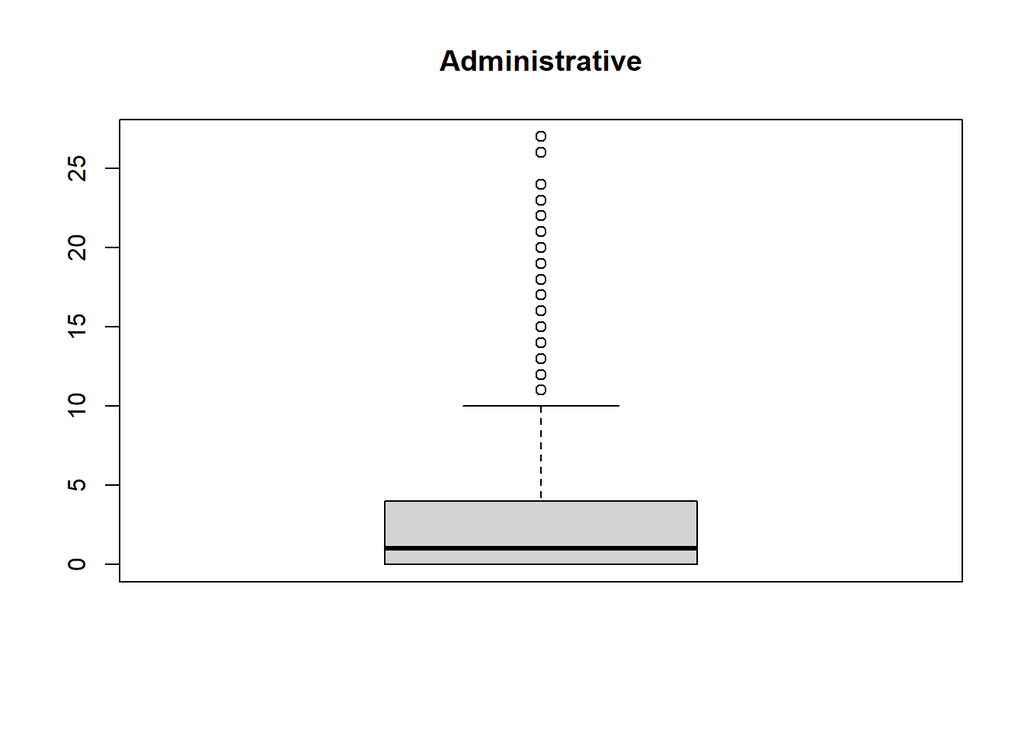

```r
boxplot(data$Administrative, main = "Administrative")
```

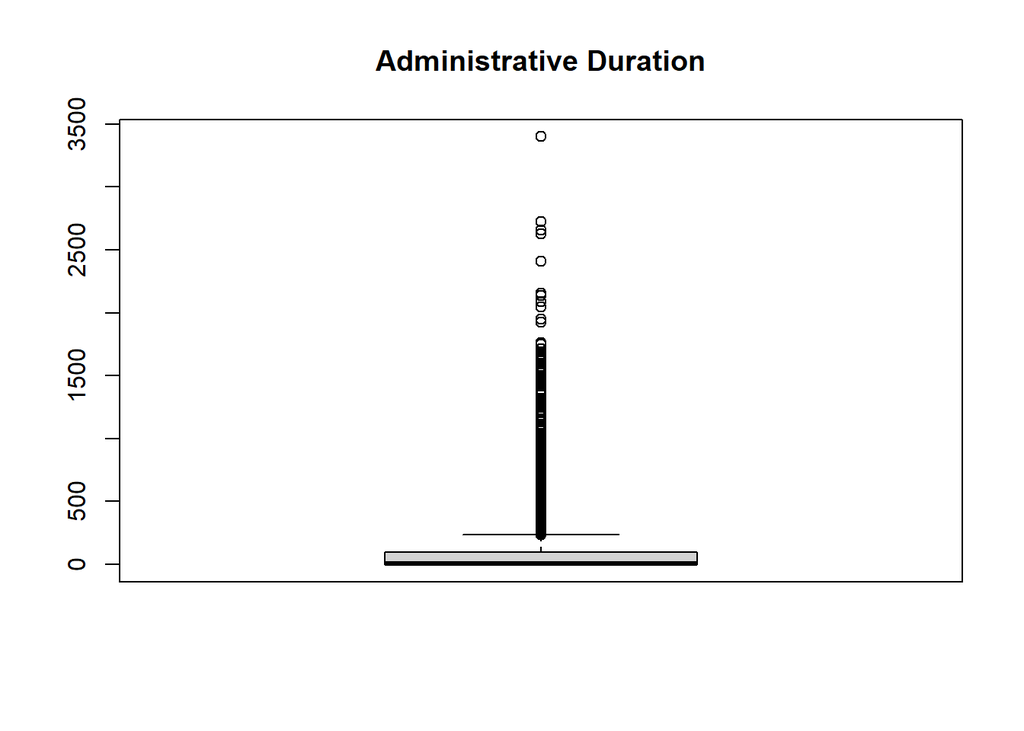

```r
boxplot(data$Administrative_Duration, main = "Administrative Duration")
```

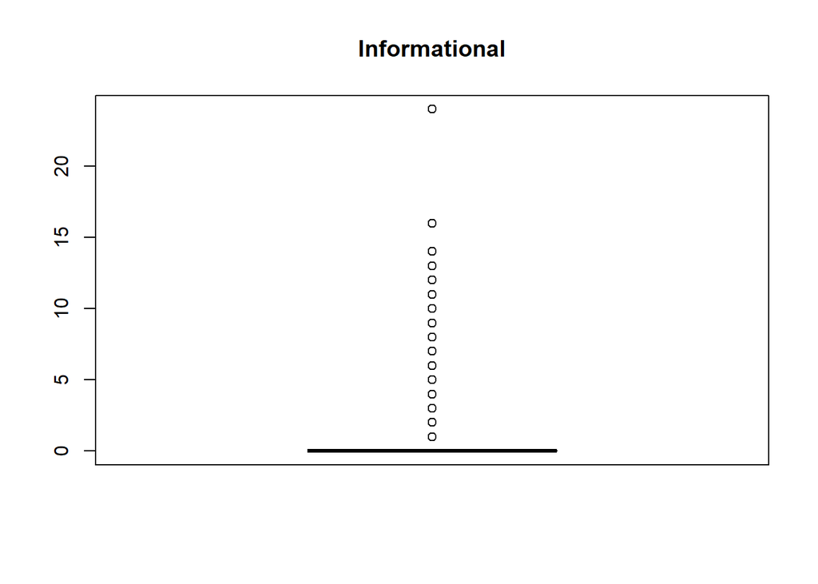

```r
boxplot(data$Informational, main = "Informational")
```

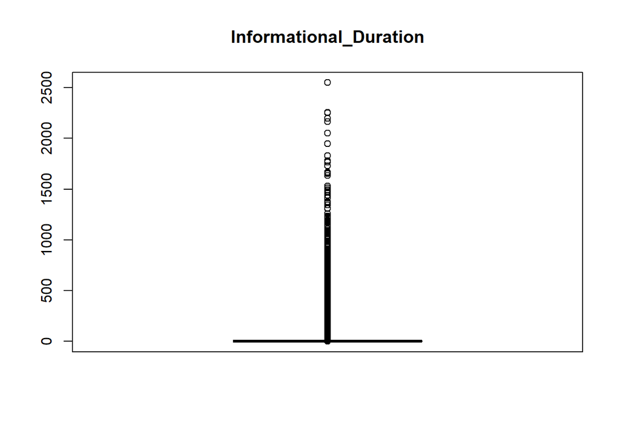

```r
boxplot(data$Informational_Duration, main = "Informational_Duration")
```

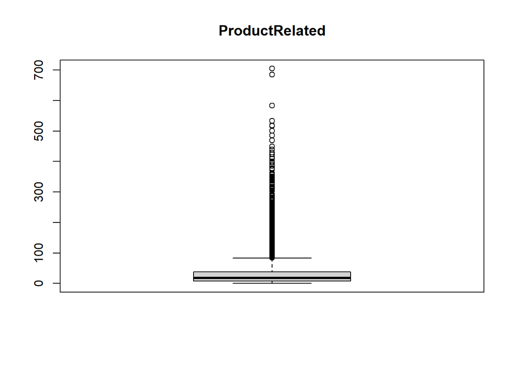

```r
boxplot(data$ProductRelated, main = "ProductRelated")
```

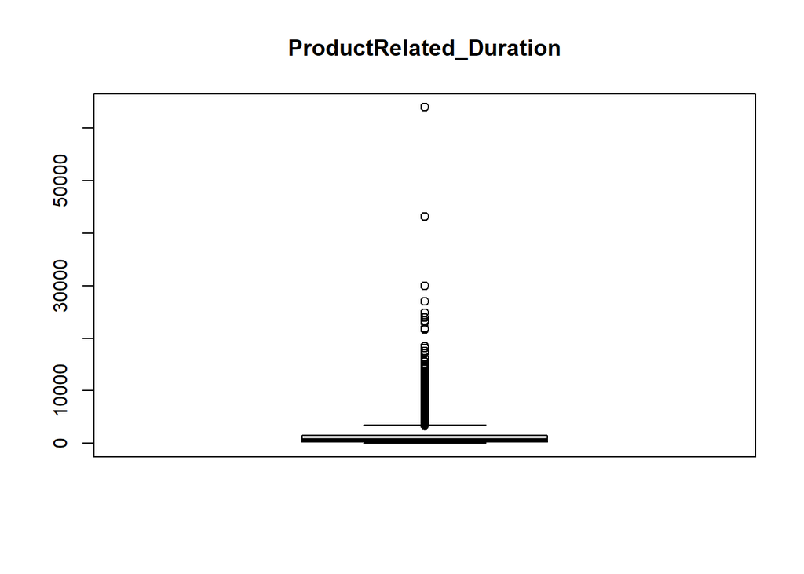

```r
boxplot(data$ProductRelated_Duration, main = "ProductRelated_Duration")
```

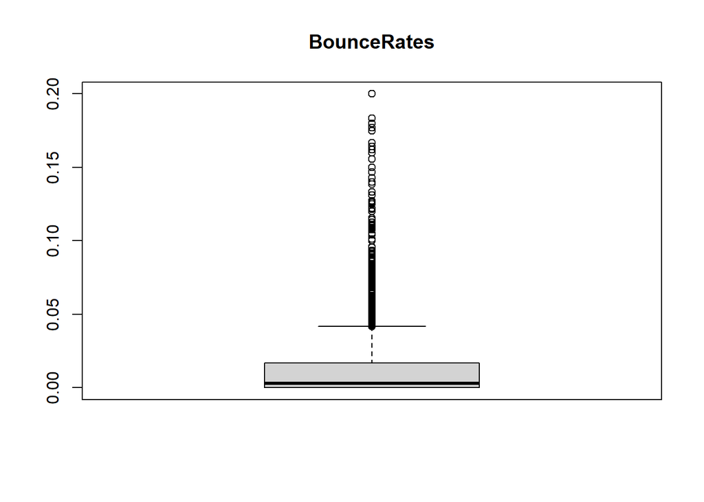

```r
boxplot(data$BounceRates, main = "BounceRates")
```

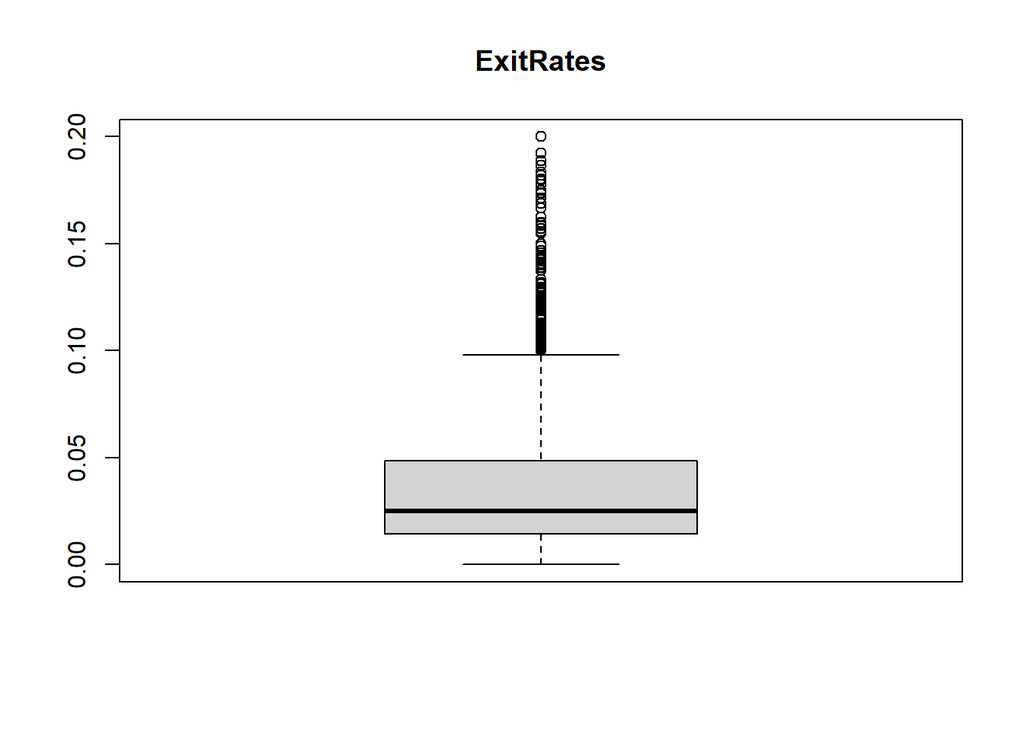

```r
boxplot(data$ExitRates, main = "ExitRates")
```

[figure not shown]

```r
boxplot(data$ExitRates, main = "PageValues")
```

```r
data2 <- data
```

```r
# install.packages("CatEncoders")
library(CatEncoders)
lenc <- LabelEncoder.fit(data2$Month)
data2$Month <- transform(lenc, data2$Month)
unique(data2$Month)
```

```
##  [1]  3  6  7  9  5  4  1  8 10  2
```

```r
lenc <- LabelEncoder.fit(data2$VisitorType)
data2$VisitorType <- transform(lenc, data2$VisitorType)
unique(data2$VisitorType)
```

```
## [1] 3 1 2
```

```r
lenc <- LabelEncoder.fit(data2$VisitorType)
data2$VisitorType <- transform(lenc, data2$VisitorType)
unique(data2$VisitorType)
```

```
## [1] 3 1 2
```

```r
lenc <- LabelEncoder.fit(data2$VisitorType)
data2$VisitorType <- transform(lenc, data2$VisitorType)
unique(data2$VisitorType)
```

```
## [1] 3 1 2
```

```r
data3 <- data2
data2 = subset(data2, select = -c(Revenue) )
colnames(data2)
```

```
##  [1] "Administrative"          "Administrative_Duration"
##  [3] "Informational"           "Informational_Duration"
##  [5] "ProductRelated"          "ProductRelated_Duration"
##  [7] "BounceRates"             "ExitRates"
##  [9] "PageValues"              "SpecialDay"
## [11] "Month"                   "OperatingSystems"
## [13] "Browser"                 "Region"
## [15] "TrafficType"             "VisitorType"
## [17] "Weekend"
```

# Perform Exploratory Data Analysis

## Univariate Analysis

### Mean

Administrative

```r
data.administrative.mean <- mean(data$Administrative)
data.administrative.mean
```

```
## [1] 2.340028
```

Administrative_Duration

```r
data.administrative.duration.mean <- mean(data$Administrative_Duration)
data.administrative.duration.mean
```

```
## [1] 81.68214
```

Informational

```r
data.informational.mean <- mean(data$Informational)
data.informational.mean
```

```
## [1] 0.5088122
```

Informational_Duration

```r
data.informational.duration.mean <- mean(data$Informational_Duration)
data.informational.duration.mean
```

```
## [1] 34.83734
```

ProductRelated

```r
data.product.related.mean <- mean(data$ProductRelated)
data.product.related.mean
```

```
## [1] 32.05845
```

ProductRelated_Duration

```r
data.product.related.duration.mean <- mean(data$ProductRelated_Duration)
data.product.related.duration.mean
```

```
## [1] 1207.508
```

BounceRates

```r
data.bounce.rates.mean <- mean(data$BounceRates)
data.bounce.rates.mean
```

```
## [1] 0.02044674
```

ExitRates

```r
data.exit.rates.mean <- mean(data$ExitRates)
data.exit.rates.mean
```

```
## [1] 0.04149678
```

```r
data.administrative.mean <- mean(data$Administrative)
data.administrative.mean
```

```
## [1] 2.340028
```

### Median

Administrative

```r
data.administrative.median <- median(data$Administrative)
data.administrative.median
```

```
## [1] 1
```

Administrative_Duration

```r
data.administrative.duration.median <- median(data$Administrative_Duration)
data.administrative.duration.median
```

```
## [1] 9
```

Informational

```r
data.informational.median <- median(data$Informational)
data.informational.median
```

```
## [1] 0
```

Informational_Duration

```r
data.informational.duration.median <- median(data$Informational_Duration)
data.informational.duration.median
```

```
## [1] 0
```

ProductRelated

```r
data.product.related.median <- median(data$ProductRelated)
data.product.related.median
```

```
## [1] 18
```

ProductRelated_Duration

```r
data.product.related.duration.median <- median(data$ProductRelated_Duration)
data.product.related.duration.median
```

```
## [1] 609.5417
```

BounceRates

```r
data.bounce.rates.median <- median(data$BounceRates)
data.bounce.rates.median
```

```
## [1] 0.002930403
```

ExitRates

```r
data.exit.rates.median <- median(data$ExitRates)
data.exit.rates.median
```

```
## [1] 0.025
```

```r
data.administrative.median<- median(data$Administrative)
data.administrative.median
```

```
## [1] 1
```

### Mode

```r
getmode <- function(v) {
   uniqv <- unique(v)
   uniqv[which.max(tabulate(match(v, uniqv)))]
}
```

Month

```r
data.month.mode <- getmode(data$Month)
```

OperatingSystems

```r
data.operating.system.mode <- getmode(data$OperatingSystems)
```

Browser

```r
data.browser.mode <- getmode(data$Browser)
```

Region

```r
data.region.mode <- getmode(data$Region)
```

TrafficType

```r
data.traffic.type.mode <- getmode(data$TrafficType)
```

VisitorType

```r
data.visitor.type.mode <- getmode(data$VisitorType)
```

Weekend

```r
data.weekend.mode<- getmode(data$Weekend)
```

Revenue

```r
data.revenue.mode <- getmode(data$Revenue)
```

### Measures of Dispersion

#### Minimum value

Administrative

```r
data.administrative.min <- min(data$Administrative)
data.administrative.min
```

```
## [1] 0
```

Administrative_Duration

```r
data.administrative.duration.min <- min(data$Administrative_Duration)
data.administrative.duration.min
```

```
## [1] -1
```

Informational

```r
data.informational.min <- min(data$Informational)
data.informational.min
```

```
## [1] 0
```

Informational_Duration

```r
data.informational.duration.min <- min(data$Informational_Duration)
data.informational.duration.min
```

```
## [1] -1
```

ProductRelated

```r
data.product.related.min <- min(data$ProductRelated)
data.product.related.min
```

```
## [1] 0
```

ProductRelated_Duration

```r
data.product.related.duration.min <- min(data$ProductRelated_Duration)
data.product.related.duration.min
```

```
## [1] -1
```

BounceRates

```r
data.bounce.rates.min <- min(data$BounceRates)
data.bounce.rates.min
```

```
## [1] 0
```

ExitRates

```r
data.exit.rates.min <- min(data$ExitRates)
data.exit.rates.min
```

```
## [1] 0
```

```r
data.administrative.max <- max(data$Administrative)
data.administrative.max
```

```
## [1] 27
```

#### Maximum value

Administrative

```r
data.administrative.max <- max(data$Administrative)
data.administrative.max
```

```
## [1] 27
```

Administrative_Duration

```r
data.administrative.duration.max <- max(data$Administrative_Duration)
data.administrative.duration.max
```

```
## [1] 3398.75
```

Informational

```r
data.informational.max <- max(data$Informational)
data.informational.max
```

```
## [1] 24
```

Informational_Duration

```r
data.informational.duration.max <- max(data$Informational_Duration)
data.informational.duration.max
```

```
## [1] 2549.375
```

ProductRelated

```r
data.product.related.max <- max(data$ProductRelated)
data.product.related.max
```

```
## [1] 705
```

ProductRelated_Duration

```r
data.product.related.duration.max <- max(data$ProductRelated_Duration)
data.product.related.duration.max
```

```
## [1] 63973.52
```

BounceRates

```r
data.bounce.rates.max <- max(data$BounceRates)
data.bounce.rates.max
```

```
## [1] 0.2
```

ExitRates

```r
data.exit.rates.max <- max(data$ExitRates)
data.exit.rates.max
```

```
## [1] 0.2
```

```r
data.administrative.max <- max(data$Administrative)
data.administrative.max
```

```
## [1] 27
```

#### Range

Administrative

```r
data.administrative.range <- range(data$Administrative)
data.administrative.range
```

```
## [1]  0 27
```

Administrative_Duration

```r
data.administrative.duration.range <- range(data$Administrative_Duration)
data.administrative.duration.range
```

```
## [1]   -1.00 3398.75
```

Informational

```r
data.informational.range <- range(data$Informational)
data.informational.range
```

```
## [1]  0 24
```

Informational_Duration

```r
data.informational.duration.range <- range(data$Informational_Duration)
data.informational.duration.range
```

```
## [1]   -1.000 2549.375
```

ProductRelated

```r
data.product.related.range <- range(data$ProductRelated)
data.product.related.range
```

```
## [1]   0 705
```

ProductRelated_Duration

```r
data.product.related.duration.range <- range(data$ProductRelated_Duration)
data.product.related.duration.range
```

```
## [1]    -1.00 63973.52
```

BounceRates

```r
data.bounce.rates.range <- range(data$BounceRates)
data.bounce.rates.range
```

```
## [1] 0.0 0.2
```

ExitRates

```r
data.exit.rates.range <- range(data$ExitRates)
data.exit.rates.range
```

```
## [1] 0.0 0.2
```

```r
data.administrative.range <- range(data$Administrative)
data.administrative.range
```

```
## [1]  0 27
```

#### Quantile

Administrative

```r
data.administrative.quantile <- quantile(data$Administrative)
data.administrative.quantile
```

```
##   0%  25%  50%  75% 100%
##    0    0    1    4   27
```

Administrative_Duration

```r
data.administrative.duration.quantile <- quantile(data$Administrative_Duration)
data.administrative.duration.quantile
```

```
##      0%     25%     50%     75%    100%
##   -1.00    0.00    9.00   94.75 3398.75
```

Informational

```r
data.informational.quantile <- quantile(data$Informational)
data.informational.quantile
```

```
##   0%  25%  50%  75% 100%
##    0    0    0    0   24
```

Informational_Duration

```r
data.informational.duration.quantile <- quantile(data$Informational_Duration)
data.informational.duration.quantile
```

```
##       0%      25%      50%      75%     100%
##   -1.000    0.000    0.000    0.000 2549.375
```

ProductRelated

```r
data.product.related.quantile <- quantile(data$ProductRelated)
data.product.related.quantile
```

```
##   0%  25%  50%  75% 100%
##    0    8   18   38  705
```

ProductRelated_Duration

```r
data.product.related.duration.quantile <- quantile(data$ProductRelated_Duration)
data.product.related.duration.quantile
```

```
##         0%        25%        50%        75%       100%
##    -1.0000   193.5833   609.5417  1477.5648 63973.5222
```

BounceRates

```r
data.bounce.rates.quantile <- quantile(data$BounceRates)
data.bounce.rates.quantile
```

```
##          0%         25%         50%         75%        100%
## 0.000000000 0.000000000 0.002930403 0.016666667 0.200000000
```

ExitRates

```r
data.exit.rates.quantile <- quantile(data$ExitRates)
data.exit.rates.quantile
```

```
##         0%        25%        50%        75%       100%
## 0.00000000 0.01422258 0.02500000 0.04848485 0.20000000
```

```r
data.administrative.quantile <- quantile(data$Administrative)
data.administrative.quantile
```

```
##   0%  25%  50%  75% 100%
##    0    0    1    4   27
```

#### Variance

Administrative

```r
data.administrative.variance <- var(data$Administrative)
data.administrative.variance
```

```
## [1] 11.09457
```

Administrative_Duration

```r
data.administrative.duration.variance <- var(data$Administrative_Duration)
data.administrative.duration.variance
```

```
## [1] 31516.25
```

Informational

```r
data.informational.variance <- var(data$Informational)
data.informational.variance
```

```
## [1] 1.62771
```

Informational_Duration

```r
data.informational.duration.variance <- var(data$Informational_Duration)
data.informational.duration.variance
```

```
## [1] 20010.51
```

ProductRelated

```r
data.product.related.variance <- var(data$ProductRelated)
data.product.related.variance
```

```
## [1] 1989.241
```

ProductRelated_Duration

```r
data.product.related.duration.variance <- var(data$ProductRelated_Duration)
data.product.related.duration.variance
```

```
## [1] 3686121
```

BounceRates

```r
data.bounce.rates.variance <- var(data$BounceRates)
data.bounce.rates.variance
```

```
## [1] 0.002061387
```

ExitRates

```r
data.exit.rates.variance <- var(data$ExitRates)
data.exit.rates.variance
```

```
## [1] 0.0021388
```

```r
data.administrative.variance <- var(data$Administrative)
data.administrative.variance
```

```
## [1] 11.09457
```

#### Standard Deviation

Administrative

```r
data.administrative.standard.deviation <- sd(data$Administrative)
data.administrative.standard.deviation
```

```
## [1] 3.330851
```

Administrative_Duration

```r
data.administrative.duration.standard.deviation <- sd(data$Administrative_Duration)
data.administrative.duration.standard.deviation
```

```
## [1] 177.5282
```

Informational

```r
data.informational.standard.deviation <- sd(data$Informational)
data.informational.standard.deviation
```

```
## [1] 1.275817
```

Informational_Duration

```r
data.informational.duration.standard.deviation <- sd(data$Informational_Duration)
data.informational.duration.standard.deviation
```

```
## [1] 141.4585
```

ProductRelated

```r
data.product.related.standard.deviation <- sd(data$ProductRelated)
data.product.related.standard.deviation
```

```
## [1] 44.60091
```

ProductRelated_Duration

```r
data.product.related.duration.standard.deviation <- sd(data$ProductRelated_Duration)
data.product.related.duration.standard.deviation
```

```
## [1] 1919.927
```

BounceRates

```r
data.bounce.rates.standard.deviation <- sd(data$BounceRates)
data.bounce.rates.standard.deviation
```

```
## [1] 0.0454025
```

ExitRates

```r
data.exit.rates.standard.deviation <- sd(data$ExitRates)
data.exit.rates.standard.deviation
```

```
## [1] 0.04624716
```

```r
data.administrative.standard.deviation <- sd(data$Administrative)
data.administrative.standard.deviation
```

```
## [1] 3.330851
```

```r
data_y <- data[data$Revenue==TRUE,]
data_n <- data[data$Revenue==FALSE,]
```

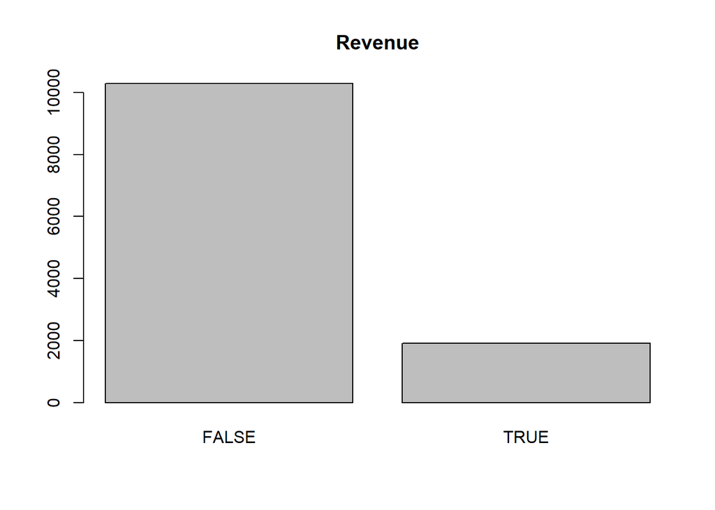

```r
barplot(table(data$Revenue), main = "Revenue")
```

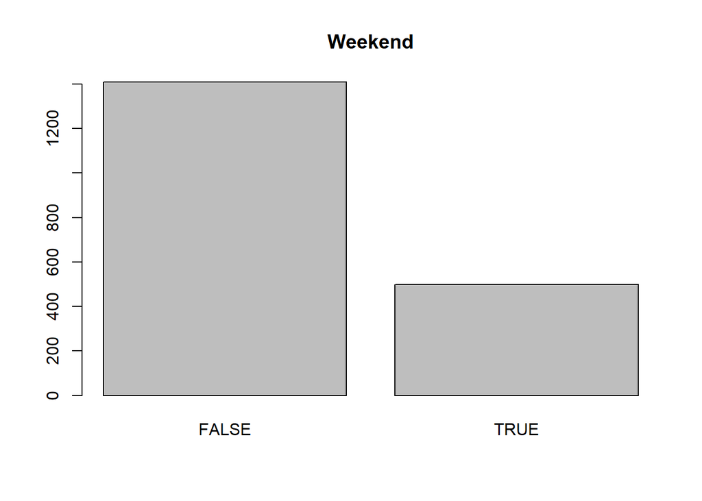

```r
barplot(table(data_y$Weekend), main = "Weekend")
```

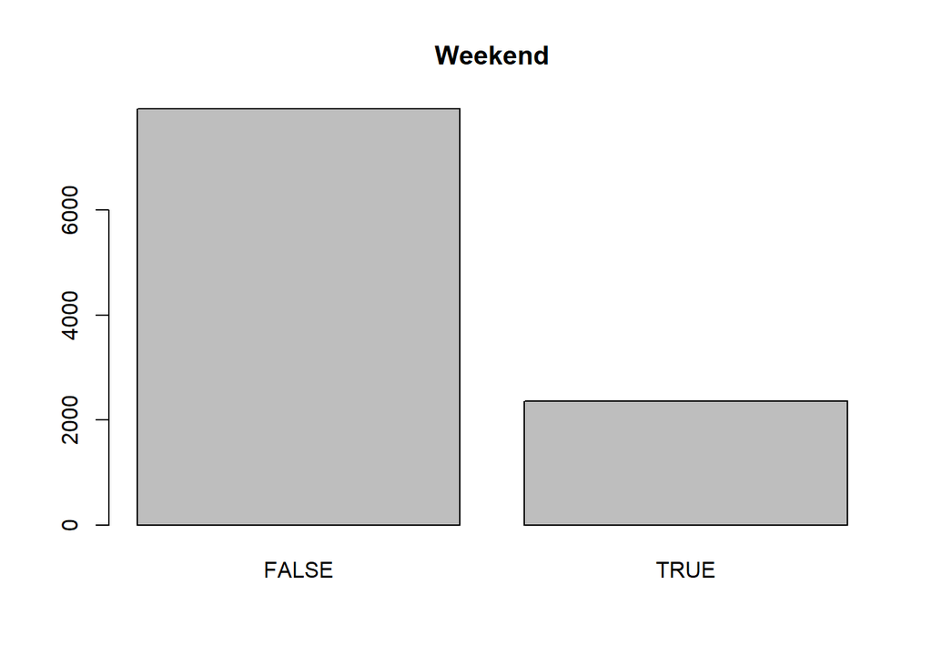

```r
barplot(table(data_n$Weekend), main = "Weekend")
```

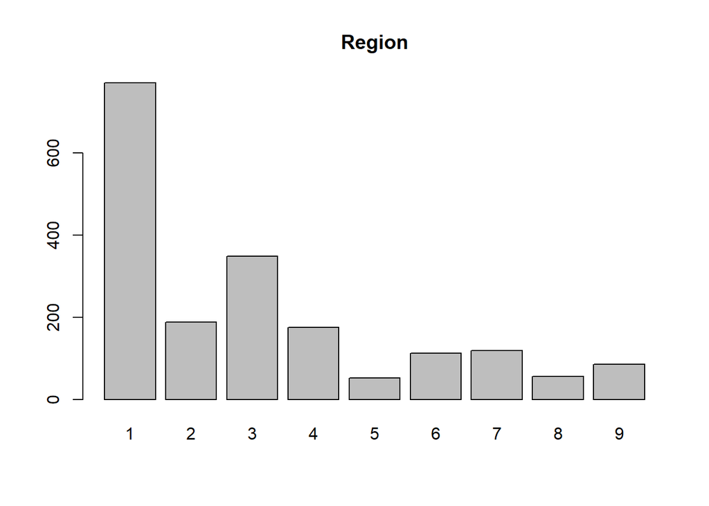

```r
barplot(table(data_y$Region), main = "Region")
```

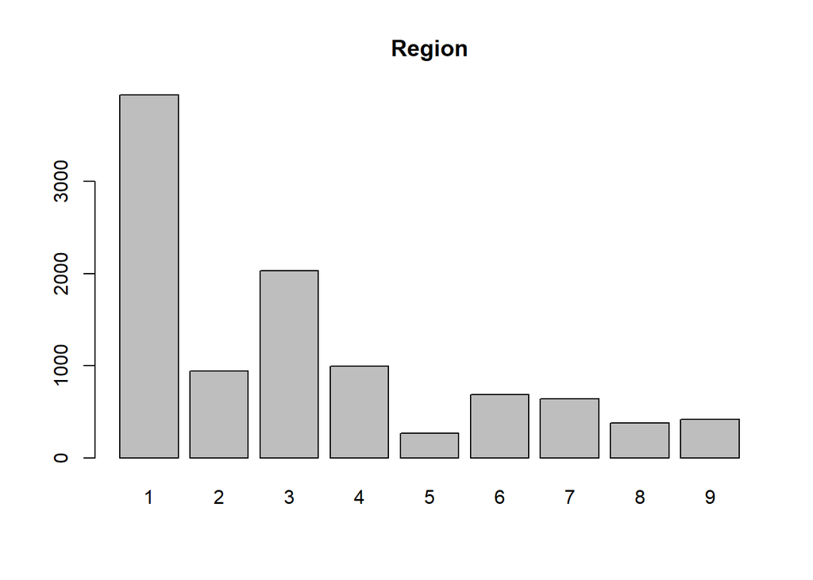

```r
barplot(table(data_n$Region), main = "Region")
```

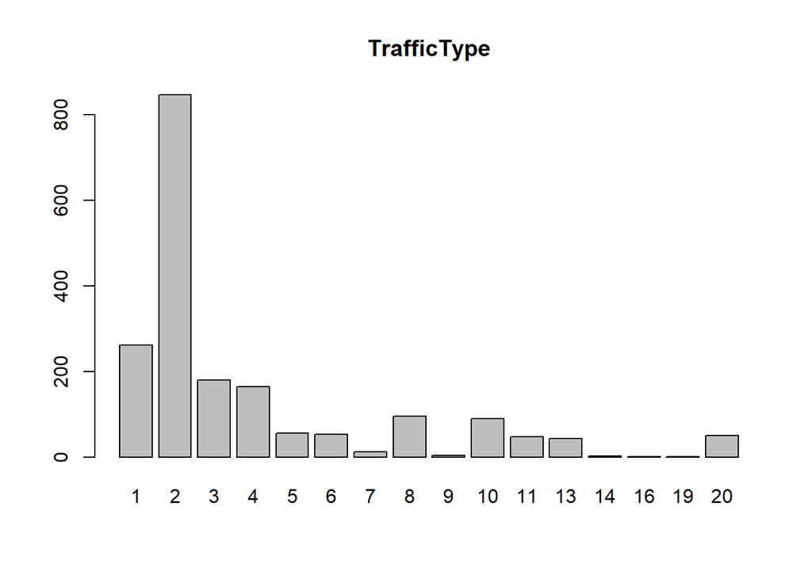

```r
barplot(table(data_y$TrafficType), main = "TrafficType")
```

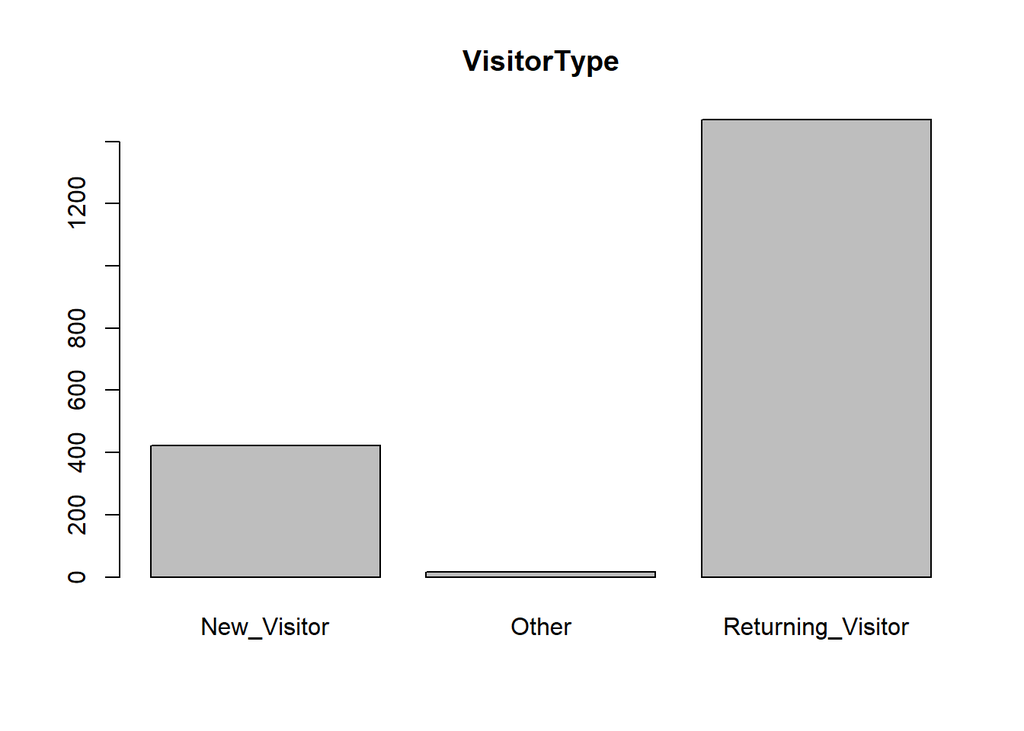

```r
barplot(table(data_y$VisitorType), main = "VisitorType")
```

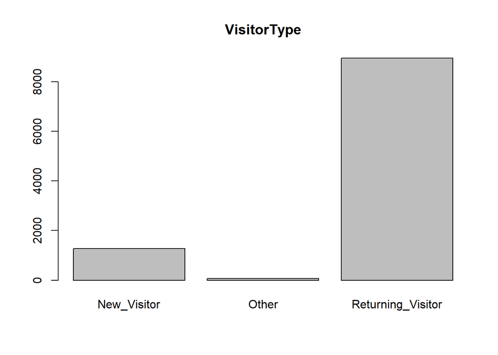

```r
barplot(table(data_n$VisitorType), main = "VisitorType")
```

## Bivariate Analysis

```r
#install.packages("magrittr") # package installations are only needed the first time you use it
#install.packages("dplyr")    # alternative installation of the %>%
library(magrittr) # needs to be run every time you start R and want to use %>%
library(dplyr)    # alternatively, this also loads %>%
names(data)[names(data) == "Administrative"] <- "adm"
names(data)[names(data) == "Administrative_Duration"] <- "adm_du"
names(data)[names(data) == "Informational"] <- "info"
names(data)[names(data) == "Informational_Duration"] <- "info_du"
names(data)[names(data) == "ProductRelated"] <- "pr"
names(data)[names(data) == "ProductRelated_Duration"] <- "pr_du"
names(data)[names(data) == "BounceRates"] <- "br"
names(data)[names(data) == "ExitRates"] <- "er"
names(data)[names(data) == "PageValues"] <- "pv"
names(data)[names(data) == "SpecialDay"] <- "sd"
```

```r
#cor_data <- data[, c('Administrative', 'Administrative_Duration', 'Informational', 'Informational_Duration', 'ProductRelated', 'ProductRelated_Duration', 'BounceRates', 'ExitRates', 'PageValues', 'SpecialDay')]
cor_data <- data %>% select(1:10)
res <- cor(cor_data, cor_data)
round(res, 2)
```

```
##           adm adm_du  info info_du    pr pr_du    br    er    pv    sd
## adm      1.00   0.60  0.38    0.25  0.43  0.37 -0.21 -0.31  0.10 -0.10
## adm_du   0.60   1.00  0.30    0.24  0.29  0.35 -0.14 -0.20  0.07 -0.07
## info     0.38   0.30  1.00    0.62  0.37  0.39 -0.11 -0.16  0.05 -0.05
## info_du  0.25   0.24  0.62    1.00  0.28  0.35 -0.07 -0.10  0.03 -0.03
## pr       0.43   0.29  0.37    0.28  1.00  0.86 -0.19 -0.29  0.05 -0.03
## pr_du    0.37   0.35  0.39    0.35  0.86  1.00 -0.17 -0.25  0.05 -0.04
## br      -0.21  -0.14 -0.11   -0.07 -0.19 -0.17  1.00  0.90 -0.12  0.09
## er      -0.31  -0.20 -0.16   -0.10 -0.29 -0.25  0.90  1.00 -0.17  0.12
## pv       0.10   0.07  0.05    0.03  0.05  0.05 -0.12 -0.17  1.00 -0.06
## sd      -0.10  -0.07 -0.05   -0.03 -0.03 -0.04  0.09  0.12 -0.06  1.00
```

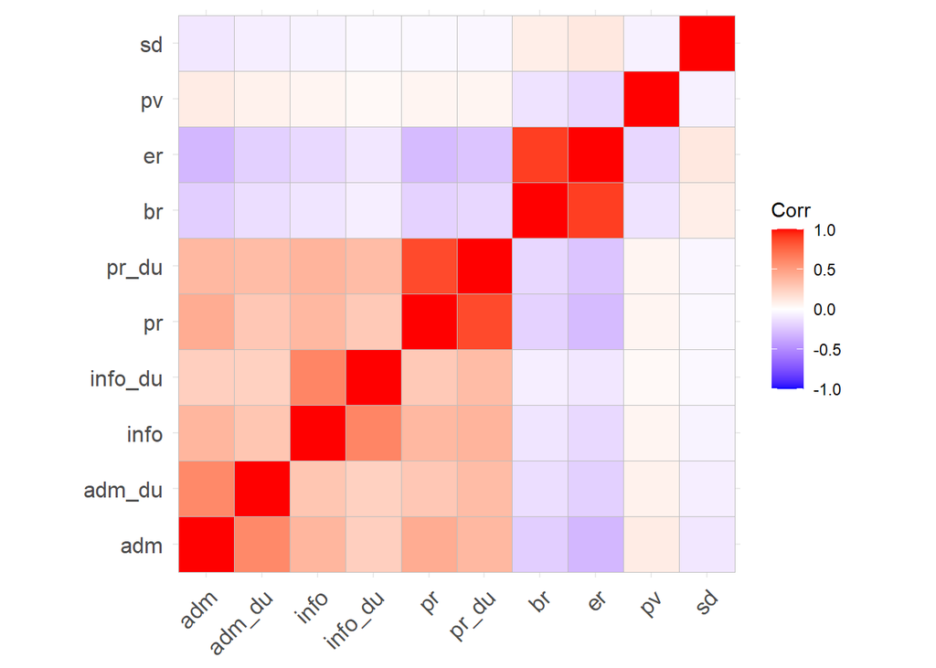

```r
#install.packages("ggcorrplot")
library(ggcorrplot)
ggcorrplot::ggcorrplot(cor(cor_data))
```

# Implement the Solution

```r
head(data)
```

|  | adm | adm_du | info | info_du | pr | pr_du | br | er | pv | sd | Month | OperatingSystems | Browser | Region | TrafficType | VisitorType | Weekend | Revenue |
| --- | --- | --- | --- | --- | --- | --- | --- | --- | --- | --- | --- | --- | --- | --- | --- | --- | --- | --- |
| 1 | 0 | 0 | 0 | 0 | 1 | 0.000000 | 0.20000000 | 0.2000000 | 0 | 0 | Feb | 1 | 1 | 1 | 1 | Returning_Visitor | FALSE | FALSE |
| 2 | 0 | 0 | 0 | 0 | 2 | 64.000000 | 0.00000000 | 0.1000000 | 0 | 0 | Feb | 2 | 2 | 1 | 2 | Returning_Visitor | FALSE | FALSE |
| 3 | 0 | -1 | 0 | -1 | 1 | -1.000000 | 0.20000000 | 0.2000000 | 0 | 0 | Feb | 4 | 1 | 9 | 3 | Returning_Visitor | FALSE | FALSE |
| 4 | 0 | 0 | 0 | 0 | 2 | 2.666667 | 0.05000000 | 0.1400000 | 0 | 0 | Feb | 3 | 2 | 2 | 4 | Returning_Visitor | FALSE | FALSE |
| 5 | 0 | 0 | 0 | 0 | 10 | 627.500000 | 0.02000000 | 0.0500000 | 0 | 0 | Feb | 3 | 3 | 1 | 4 | Returning_Visitor | TRUE | FALSE |
| 6 | 0 | 0 | 0 | 0 | 19 | 154.216667 | 0.01578947 | 0.0245614 | 0 | 0 | Feb | 2 | 2 | 1 | 3 | Returning_Visitor | FALSE | FALSE |

```r
normalize <- function(x){
  return ((x-min(x)) / (max(x)-min(x)))
}
```

```r
for(i in 1:ncol(data2)) {       # for-loop over columns
  data2[, i]<- normalize(data2[, i])
}

head(data2)
```

|  | Administrative | Administrative_Duration | Informational | Informational_Duration | ProductRelated | ProductRelated_Duration | BounceRates | ExitRates | PageValues | SpecialDay | Month | OperatingSystems | Browser | Region | TrafficType | VisitorType | Weekend |
| --- | --- | --- | --- | --- | --- | --- | --- | --- | --- | --- | --- | --- | --- | --- | --- | --- | --- |
| 1 | 0 | 0.0002941393 | 0 | 0.0003920992 | 0.001418440 | 1.563122e-05 | 1.00000000 | 1.000000 | 0 | 0 | 0.2222222 | 0.0000000 | 0.00000000 | 0.000 | 0.00000000 | 1 | 0 |
| 2 | 0 | 0.0002941393 | 0 | 0.0003920992 | 0.002836879 | 1.016029e-03 | 0.00000000 | 0.500000 | 0 | 0 | 0.2222222 | 0.1428571 | 0.08333333 | 0.000 | 0.05263158 | 1 | 0 |
| 3 | 0 | 0.0000000000 | 0 | 0.0000000000 | 0.001418440 | 0.000000e+00 | 1.00000000 | 1.000000 | 0 | 0 | 0.2222222 | 0.4285714 | 0.00000000 | 1.000 | 0.10526316 | 1 | 0 |
| 4 | 0 | 0.0002941393 | 0 | 0.0003920992 | 0.002836879 | 5.731448e-05 | 0.25000000 | 0.700000 | 0 | 0 | 0.2222222 | 0.2857143 | 0.08333333 | 0.125 | 0.15789474 | 1 | 0 |
| 5 | 0 | 0.0002941393 | 0 | 0.0003920992 | 0.014184397 | 9.824223e-03 | 0.10000000 | 0.250000 | 0 | 0 | 0.2222222 | 0.2857143 | 0.16666667 | 0.000 | 0.15789474 | 1 | 1 |
| 6 | 0 | 0.0002941393 | 0 | 0.0003920992 | 0.026950355 | 2.426226e-03 | 0.07894737 | 0.122807 | 0 | 0 | 0.2222222 | 0.1428571 | 0.08333333 | 0.000 | 0.10526316 | 1 | 0 |

```r
# install.packages("NbClust")
# install.packages("openxlsx")
#install.packages("factoextra")
library(tidyverse)
library(dplyr)
library(openxlsx)
library(NbClust)
library(factoextra)
library(readxl)
```

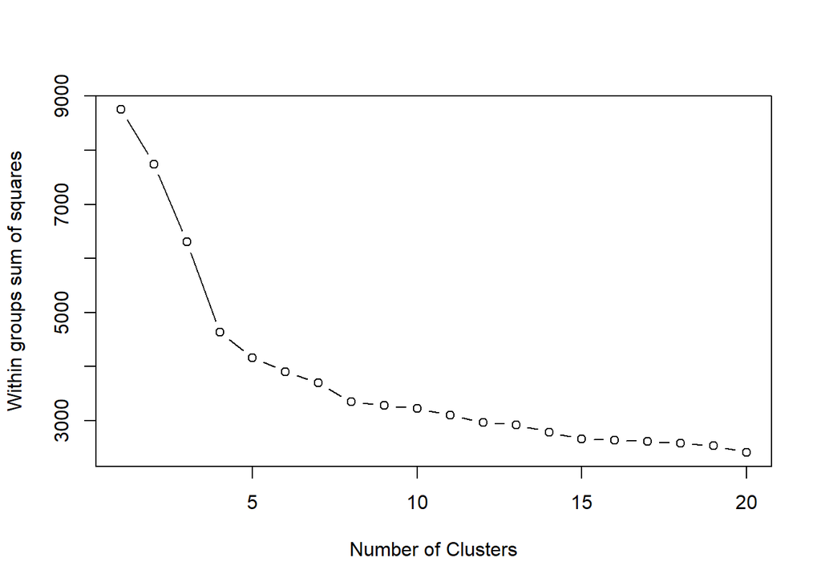

```r
data2_matrix <- data.matrix(data2)
wssplot <- function(data2_matrix, nc, seed=123){
  wss <- (nrow(data2_matrix)-1)*sum(apply(data2_matrix, 2, var))
  for (i in 2:nc){
    set.seed(seed)
    wss[i] <- sum(kmeans(data2_matrix, centers = i)$withinss)}
  plot(1:nc, wss, type = "b", xlab = "Number of Clusters", ylab = "Within groups sum of squares")
}

wssplot(data2_matrix, nc=20)
```

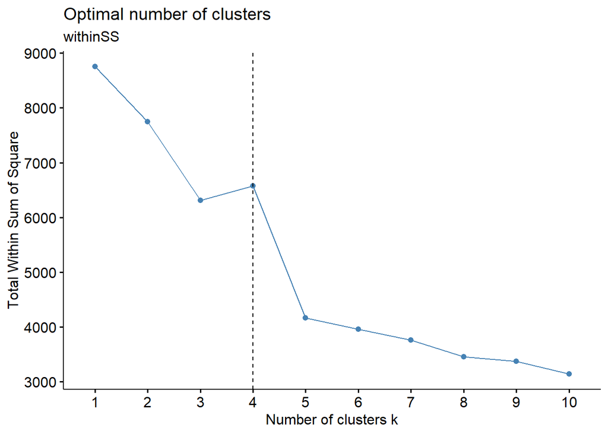

```r
fviz_nbclust(data2_matrix, kmeans, method = "wss")+
  geom_vline(xintercept = 4, linetype = 2)+
  labs(subtitle = "withinSS")
```

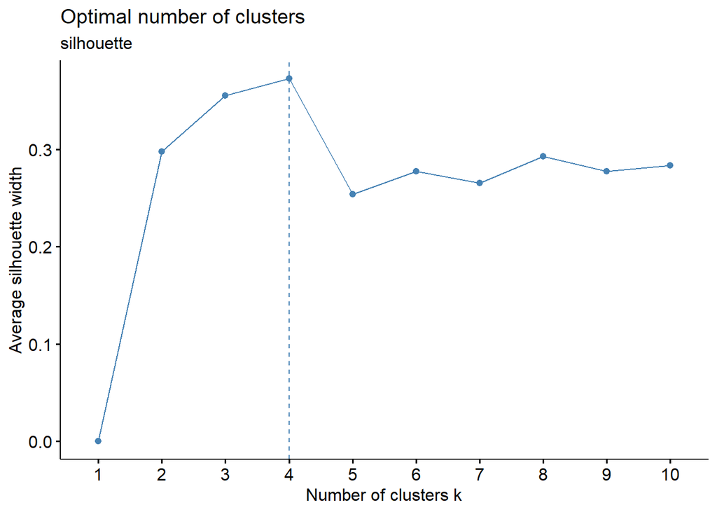

```r
fviz_nbclust(data2_matrix, kmeans, method = "silhouette")+
  labs(subtitle = "silhouette")
```

```r
result <- kmeans(data2, 4)

# Previewing the no. of records in each cluster
result$size
```

```
## [1] 7439 2261 1712  787
```